# Lecture 8: Probability distribution (continuous variables) and sampling distributions

Mathematics and Statistics

Theodoros Arvanitopoulos

2025-11-24

# Learning Objectives

### Sampling distributions

- Define the concept of a sampling distribution.
- Understand the relationship between sample and population estimates.
- Be able to calculate the best estimates of the population mean and population proportion
- Understand the importance and application of the Central Limit Theory

### 📚 Reading

Newbold et al. (2020), *Statistics for Business and Economics*, Ch. 5-6

# Probability distribution (continuous variables)

In the previous lecture we discussed about probability distribution for discreet variables

For continuous variables, probabilities are computed as areas under a curve.

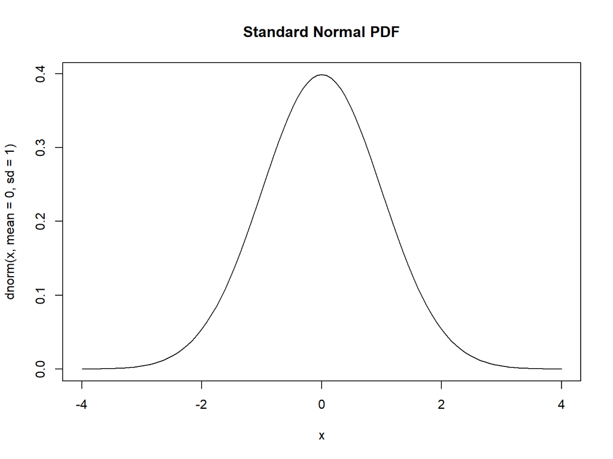

```r
curve(dnorm(x, mean = 0, sd = 1), from = -4, to = 4, main = "Standard Normal PDF")
```

# Cumulative Distribution Function (CDF)

The **CDF** of a continuous random variable $X$, denoted $F(x)$, gives the probability that $X$ does not exceed the value of $x$:

$$F(x) = P(X \leq x)$$

# Cumulative Distribution Function (CDF)

The **CDF** of a continuous random variable $X$, denoted $F(x)$, gives the probability that $X$ does not exceed the value of $x$:

$$F(x) = P(X \leq x)$$

So, if $a$ and $b$ are two possible values for $X$, with $a<b$, then the probability that $X$ lies between $a$ and $b$ is

$$P(a<X<b)=F(b)-F(a)=\int_{a}^{b}f(x)dx$$

# Cumulative Distribution Function (CDF)

The **CDF** of a continuous random variable $X$, denoted $F(x)$, gives the probability that $X$ does not exceed the value of $x$:

$$F(x) = P(X \leq x)$$

So, if $a$ and $b$ are two possible values for $X$, with $a<b$, then the probability that $X$ lies between $a$ and $b$ is

$$P(a<X<b)=F(b)-F(a)=\int_{a}^{b}f(x)dx$$

For discrete variables, this is a step function.

For continuous variables, it’s the **integral of the PDF**, and computes the area under the probability density function $f(x)$ over all values of the random variable $X$ within its range.

Thus, the cumulative distribution function $F(x_0$) is the area under the probability density function $f(x)$ from the minimum value $x_m$ up to maximum value $x_0$

$$F(x) = \int_{x_m}^{x_0} f(x) \, dx$$

# Cumulative Distribution Function (CDF)

The cumulative function $F(x)$ is the area under the probability density function $f(x)$ from the minimum value $x_m$ up to maximum value $x_0$

$$F(x) = \int_{x_m}^{x_0} f(x) \, dx$$

### CDF plot using R

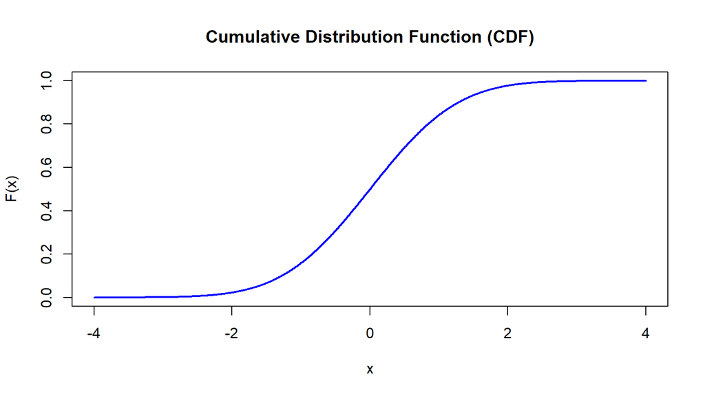

```r
x <- seq(-4, 4, length = 1000)
cdf_vals <- pnorm(x)
plot(x, cdf_vals, type = "l", col = "blue", lwd = 2,
     main = "Cumulative Distribution Function (CDF)",
     ylab = "F(x)", xlab = "x")
```

# Probability Density Function (PDF)

The **PDF** describes how dense the probability is around a point. The height of the curve is **not** probability.

**Shared area under the curve is the probability** that $X$ is between two points $a$ and $b$.

To compute $P(a \leq X \leq b)$, we integrate: $P(a \leq X \leq b) = \int_{a}^{b} f(x) \, dx$

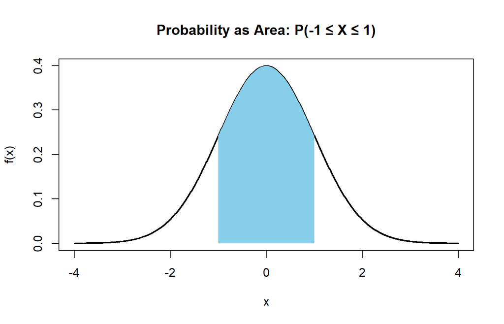

*Note*: The total area under the curve $f(x)$ is $1$, while the probability of any individual value is zero.

The area represents $P(-1 \leq X \leq 1)$, computed as:

```r
pnorm(1) - pnorm(-1)
```

```
## [1] 0.6826895
```

# Standard Normal Distribution

Standard Normal Distribution is continuous, bell-shaped, and symmetric. It is often used to model natural phenomena due to its characteristics.

**Properties of the Normal Distribution**:

- central location is determined by the mean $\mu$: $E[X]=\mu$
- variance of the random variable is $\sigma^2$: $Var(X)=E[(X-\mu)^2]=\sigma^2$
- spread is determined by the standard deviation $\sigma$
- the random variable has an infinite theoretical range from $-\infty$ to $+\infty$
- mean, median, and mode are **equal**
- PDF is symmetric, bell-shaped curve, centered on the mean $\mu$

Given the mean $\mu$ and variance $\sigma^2$, we define the normal distribution using the following notation: $X$ $\sim$ $N(\mu, \sigma^2)$

For example, a **normal distribution** with $\mu = 0$, $\sigma = 1$ looks like this:

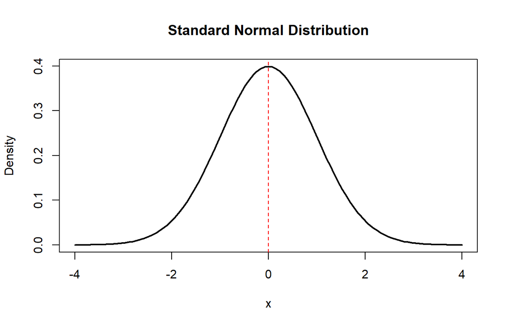

# Standard Normal Distribution

By varying the parameters $\mu$ and $\sigma$, we can obtain different normal distributions:

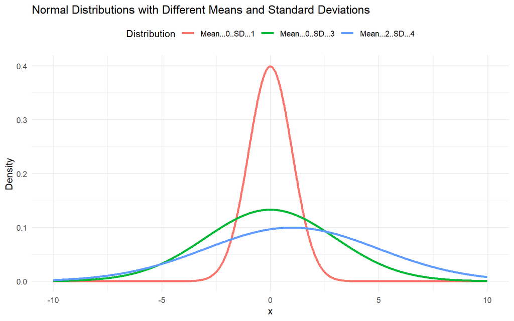

# Shading Area Under Normal Curve

For a normal random variable $X$ with mean $\mu$ and variance $\sigma^2$, i.e $X$ $\sim$ $N(\mu,\sigma^2)$, the cumulative distribution function (CDF) is:

$$F(x_0)=P(X \leq x_0)$$

and the probability for values $a$ and $b$ is measured by the area under the curve

$$P(a \leq x \leq b) = F(b)-F(a)$$

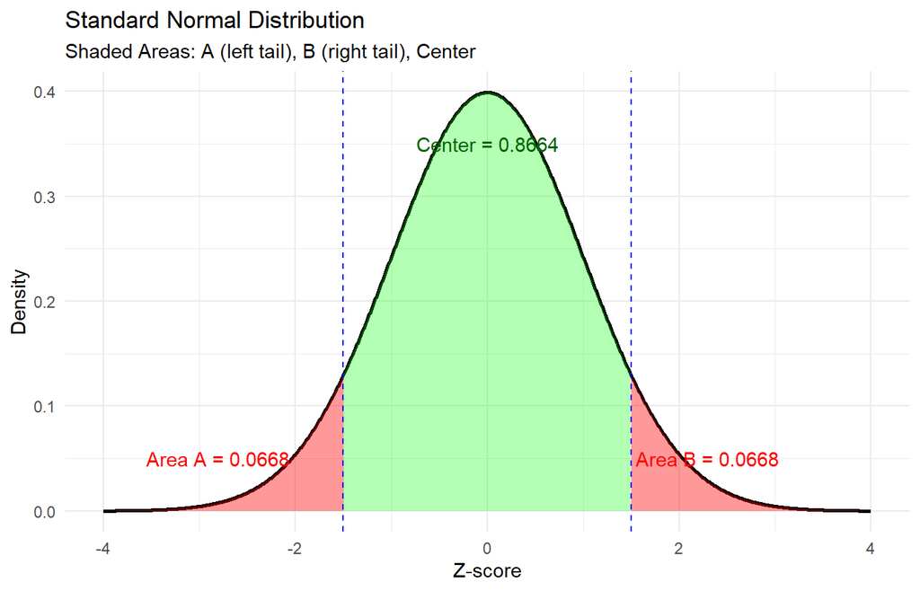

# Z-scores

Any normal distribution (with any mean and variance combination) can be transformed into the standardised normal distribution ($Z$), with mean $\mu=0$ and variance $\sigma=1$, denoted as:

$$Z \sim N(0,1)$$
To do that, we need to transform $X$ units into $Z$ units by using the following formula:

$$Z = \frac{X - \mu}{\sigma}$$

For example, if $X$ is distributed normally with mean of 100 and standard deviation of 50, the $Z$ value for $X = 200$ is

$$Z = \frac{X - \mu}{\sigma}=\frac{200 - 100}{50}= 2$$
which says that $X = 200$ is two standard deviations ($2$ increments of $50$ units) above the mean of $100$.

# The standard normal table

So, finding normal probabilities

$$P(a<X<b)=P(\frac{a-\mu}{\sigma}<Z<\frac{b-\mu}{\sigma}) \\
=F(\frac{b-\mu}{\sigma})-F(\frac{a-\mu}{\sigma})$$

The Standard Normal Distribution table shows values of the cumulative normal distribution function

For a given $Z$-value, the table shows the value for $F(a)$: *e.g.* $P(Z<2.00)=0.9772$

For the negative $Z$-values, use the fact that the distribution is symmetric to find the needed probability:

$P(Z<-2.00)=1-0.9772=0.0228$

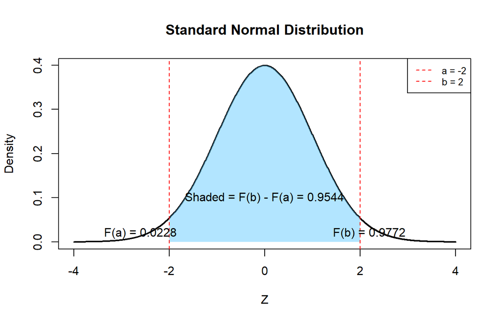

# Inferential Statistics

Using sample results to make statements about populations, i.e. **sample statistics** (known)

→ **population parameters** (unknown, but can be estimated from sample evidence)

# Inferential Statistics

Using sample results to make statements about populations, i.e. **sample statistics** (known)

→ **population parameters** (unknown, but can be estimated from sample evidence)

Two main tools:

- **Estimation** → estimate population mean using sample mean
- **Hypothesis testing** → use sample evidence to test a hypothesis (e.g. the population mean height is 1.8m/5.9feet)

# Random sampling

Why Sampling?

- Entire population is often too costly, impractical, or even not possible to get information about (examples include the UK census)
- Instead, it is possible to get statistical results of sufficiently high precision using samples
- So, a **random sample** can be used to infer about the population

# Random sampling

Why Sampling?

- Entire population is often too costly, impractical, or even not possible to get information about (examples include the UK census)
- Instead, it is possible to get statistical results of sufficiently high precision using samples
- So, a **random sample** can be used to infer about the population

Simple Random Sample (SRS):

- each individual has equal chance of selection
- objects are selected independently

```r
# Simulating a simple random sample
set.seed(123)
population <- rnorm(10000, mean = 100, sd = 15)
sample <- sample(population, 50)
mean(sample)
```

```
## [1] 100.3235
```

# Sampling Distribution of the Mean

A **sampling distribution** is a probability distribution of a **sample statistic** across many random samples $X_1, X_2, X_3,..., X_n$ from a population.

If you take many samples of size $n$, then the sample mean value for these observations is

$$\bar{X}=\frac 1 n \sum_{i=1}^{n}X_i$$

# Sampling Distribution of the Mean

A **sampling distribution** is a probability distribution of a **sample statistic** across many random samples $X_1, X_2, X_3,..., X_n$ from a population.

If you take many samples of size $n$, then the sample mean value for these observations is

$$\bar{X}=\frac 1 n \sum_{i=1}^{n}X_i$$

The mean of the sampling distribution of the sample means is the population mean:

$$E(\bar{X}) = \mu$$

# Sampling Distribution of the Mean

A **sampling distribution** is a probability distribution of a **sample statistic** across many random samples $X_1, X_2, X_3,..., X_n$ from a population.

If you take many samples of size $n$, then the sample mean value for these observations is

$$\bar{X}=\frac 1 n \sum_{i=1}^{n}X_i$$
The mean of the sampling distribution of the sample means is the population mean:

$$E(\bar{X}) = \mu$$

Different samples of the same size from the same population will yield different sample means.

The **standard error of the mean** is a measure of the variability in the mean from sample to sample:

$$\sigma_{\bar{X}} =
\frac{\sigma}{\sqrt{n}}$$

# Standard Error (SE) of the Mean

*Note*: The standard error of the mean decreases as the sample size increases.

This means that as our sample size increase, we can produce be more confident of the actual mean of the population.

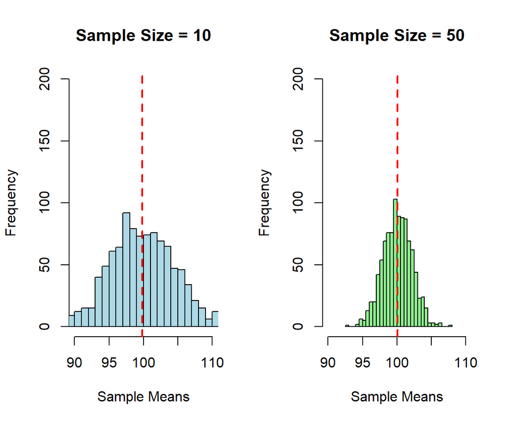

The two histograms above show the sampling distribution of the mean for two different sample sizes: $n = 10$ and $n = 50$.

Notice how the distribution with larger sample size ($n = 50$) is narrower.

→ This is because the standard error decreases as $n$ increases, making our estimate of the population mean more precise.

# Central Limit Theorem (CLT)

### Sampling distribution of means and properties

> For large enough $n$, the sampling distribution of the mean becomes approximately **normal**, regardless of the population shape.

$$\mu_\bar{X}=\mu \ \ \ \ and \ \ \ \
\sigma_\bar{x}=\frac{\sigma}{\sqrt{n}}$$
so that
$$\bar{X} \sim N\left(\mu, \frac{\sigma^2}{n}\right)$$

and as $n$ increases, $\sigma_\bar{X}$ decreases.

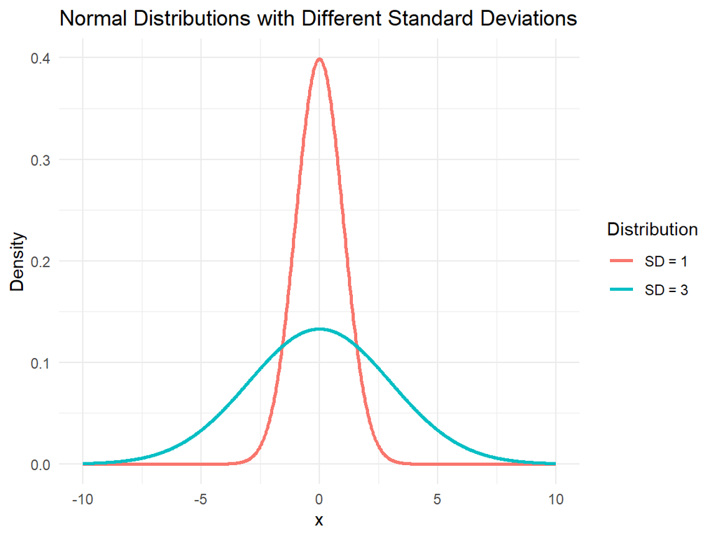

# Standard normal distribution for the sample mean

If the sampling distribution of the sample means is a normal distribution,

then we can compute a standardised normal random variable $Z$ :

$$Z= \frac{\bar{X}-\mu}{\sigma_\bar{X}}=
\frac{\bar{X}-\mu}{\frac{\sigma}{\sqrt{n}}}$$

where

- $\bar{X}$ is the sample mean
- $\mu$ is the population mean
- $\sigma_\bar{X}$ is the standard error of the mean.

So, the $Z$-value with mean 0 and variance 1 for the sampling distribution of $\bar{X}$ is
$$Z= \frac{\bar{X}-\mu}{\sqrt{\sigma^2/n}} \sim N(0,1)$$

# Central Limit Theorem (CLT)

Even if the population is not normal, sample means from the population will be approximately normal as long as the sample size is large enough.

$$\bar{X} \sim
N(\mu,\frac{\sigma^2}{n})$$

As $n$ becomes large, the central limit theorem states that the $Z$ transformation for $\bar{X}$ approaches the standard normal distribution.

$$Z=\frac{\bar{X}-\mu}{\sqrt{\sigma^2/n}} \sim N(0,1)$$

# Central Limit Theorem (CLT)

Even if the population is not normal, sample means from the population will be approximately normal as long as the sample size is large enough.

$$\bar{X} \sim N(\mu,\frac{\sigma^2}{n})$$

As $n$ becomes large, the central limit theorem states that the $Z$ transformation for $\bar{X}$ approaches the standard normal distribution.

$$Z=\frac{\bar{X}-\mu}{\sqrt{\sigma^2/n}} \sim N(0,1)$$

Under the CLT:

- the mean of all possible sample means equals the population mean $\mu=\mu_x$
- the standard deviation for all sample means is less than the standard deviation of the population $\sigma_x<\sigma$

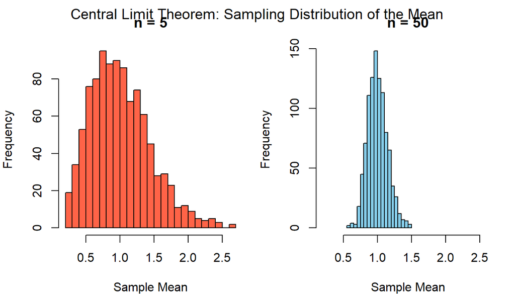

# Sampling distribution of sample proportions

Let $X$ be the number of successes in a binomial sample of $n$ observations with probability of success $P$.

The sample proportion provides an estimate of $P$

$$\hat{p} = X / n$$
where $0 \leq \hat{p} \leq 1$ and has a binomial distribution.

# Sampling distribution of sample proportions

Let $X$ be the number of successes in a binomial sample of $n$ observations with probability of success $P$.

The sample proportion provides an estimate of $P$

$$\hat{p} = X / n$$
where $0 \leq \hat{p} \leq 1$ and has a binomial distribution.

Suppose we are sampling from a population in which the probability of a ‘success’ on any trial is $P$, and $P$ is unknown.

Then for all possible samples of size $n$ sufficiently large, the distribution of sample proportions will be

$$\hat{p} \sim N \ (P, \ \ \sigma_{\hat{p}} = \sqrt{ \frac{P(1 - P)}{n}})$$

# Sampling distribution of sample proportions

Let $X$ be the number of successes in a binomial sample of $n$ observations with probability of success $P$.

The sample proportion provides an estimate of $P$

$$\hat{p} = X / n$$
where $0 \leq \hat{p} \leq 1$ and has a binomial distribution.

Suppose we are sampling from a population in which the probability of a ‘success’ on any trial is $P$, and $P$ is unknown.

Then for all possible samples of size $n$ sufficiently large, the distribution of sample proportions will be

$$\hat{p} \sim N \ (P, \ \ \sigma_{\hat{p}} = \sqrt{ \frac{P(1 - P)}{n}})$$

Given sample size is large enough, and based on CLT,

$$Z = \frac{\hat{p}-P}{\sqrt{ \frac{P(1 - P)}{n}}} =
\frac{\hat{p}-P}{\sigma_\hat{p}}$$
So, the $\hat{p}$ has binomial distribution, but can be approximated by a standard normal distribution when $nP(1 – P) > 5$

# Sampling Distribution of the Proportion - R Example

> In a population, 40% support a policy. Sample size = 200.  
> What is the probability that less than 35% in the sample support the policy ?

So, $P(\hat{p}<0.35)$ where $\hat{p}$ is the sample proportion

This is a normal approximation problem using the sampling distribution of the proportion $Z = \frac{\hat{p}-P}{\sigma_\hat{p}}$

```r
# Set known parameters
P <- 0.4       # true population proportion
n <- 200       # sample size
phat <- 0.35   # sample proportion for which we compute the probability

# Calculate standard error of sample proportion
se <- sqrt(P * (1 - P) / n)

# Compute Z-score
z <- (phat - P) / se

# Find probability using standard normal distribution
probability <- pnorm(z)

# Output results
list(Z_score = round(z, 2), Probability = round(probability, 4))
```

```
## $Z_score
## [1] -1.44
##
## $Probability
## [1] 0.0745
```

# Sampling Distribution of the Proportion - Visualisation using R

We used the central limit theorem to approximate the sampling distribution of the sample proportion with a normal distribution.

Since the population proportion is known to be 0.4, we computed the probability that the observed sample proportion would be less than 0.35,

i.e. $P(\hat{p} < 0.35)$ → this is visually represented by the shaded area.

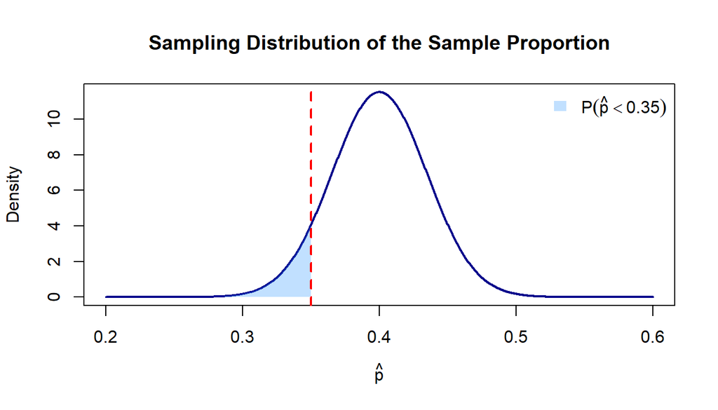